# Chap. 5.1.2

Max

avril 2021

# Networks of hosts

There are cases where the housing unit is not re-listed by the same host account. Therefore, we nested all accounts listing the same housing units under one network. This can lead to the creation of vast networks of hosts. As an example, in a previous report prepared by UPGo and submitted to Projet Montreal, we identified, in Montreal, a specific network of hosts whose 880 listings earned approximately $12.9 million in 2019. An investigation into a sample of the host accounts which make up this network suggests links between several prominent property management companies in Montreal—notably a cluster of co-ownership and shared employees among realty companies and various short-term rental brands.

In this research project, the previous 122,238 distinct host accounts were nested into 116,614 networks of hosts. For the sake of simplicity, from here on we will refer to host networks when we talk about these 116,614, even for accounts that are not part of networks. If two different host accounts posted listings with identical or nearly-identical photos in the same city, then we considered the owner was the same individual, or the same operation. We uncovered 135 networks that operated more than 50 listings anywhere in the 10 largest STR market in North America. The biggest network posted 41,255 listings since November 2009.

This particular network is however extraordinary. It is 27 times larger than the second largest network of hosts, which posted 1,550 listings. Further analysis let us uncover that this network merged 1,234 host accounts, mostly sharing photos of properties in Kissimme and Davenport. It is combining host accounts from a highly commercial network of property owner or property management companies, since 79 host accounts part of this network posted at least 100 listings since their account’s creation. Their merging into one network is supported by the evidence: the density of matches between these 79 commercial host accounts is very high. Indeed, the density of matches between all of these hosts, if we pair together every host account that matched at least once, is at 10.0%. For every pair of host accounts that had matching photos, for every 100 listings these hosts posted, an average of ten of them were sharing the same listing’s image. Moreover, still in this network, if we look at the 8 host accounts which posted more than 1,000 listings since their account’s creation, the figure is of 25.4%. It lets us believe that these host accounts are, indeed, part of the same network of hosts.

Again, this network is mostly active in Kissimmee and Davenport, and the matches were mostly photos of resorts. Once we filter out the listings from these cities, this particular network shrinks down to 1,458 listings, shared among the 8 other largest STR market in North America.

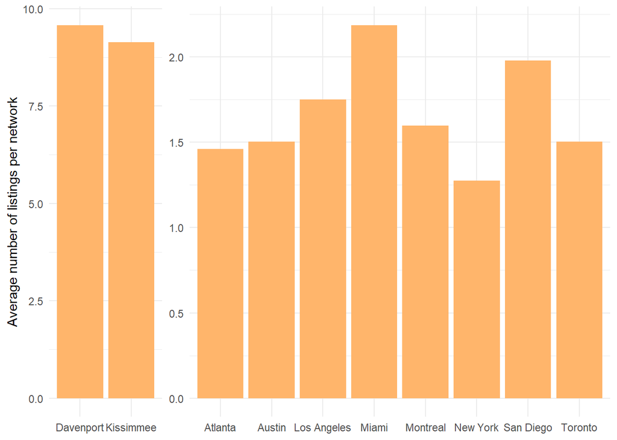

```
## [1] 36305
```

```
## # A tibble: 10 x 7
##    City   Properties `Recycled listi~ Networks `Properties per~ `Properties ope~
##    <chr>  <chr>      <chr>            <chr>    <chr>            <chr>
##  1 New Y~ 45,000     1,369            35,297   1.27             1,076
##  2 Kissi~ 36,888     1,831            4,035    9.14             28,367
##  3 Montr~ 24,692     656              15,452   1.6              580
##  4 Los A~ 23,945     487              13,681   1.75             584
##  5 Toron~ 23,395     407              15,562   1.5              229
##  6 Atlan~ 16,959     301              11,601   1.46             206
##  7 Daven~ 13,806     704              1,442    9.57             11,430
##  8 Austin 13,204     170              8,783    1.5              241
##  9 San D~ 12,178     123              6,150    1.98             335
## 10 Miami  12,069     208              5,519    2.19             287
## # ... with 1 more variable: x <chr>
```

```
## # A tibble: 2 x 6
## # Groups:   Network, Frequently rented properties (FREH) [2]
##   Network `Frequently rented~ `Number of prop~ `Number of host~ `FREH / propert~
##   <lgl>                 <int> <chr>            <chr>            <chr>
## 1 FALSE                 32488 137,863          111,174          23.6%
## 2 TRUE                  24272 84,273           5,440            28.8%
## # ... with 1 more variable: Properties / host <chr>
```

Networks of hosts will, almost by definition, be multilisters, meaning they will operate more than one listing at the same time. It means they are commercial hosts since they cannot operate all these listings out of their principal residence. Indeed, a network of host will have, on average, 15.49 properties listed on Airbnb, while a singular host will have only 1.24. In addition to the multilisting variable which lets us learn if a host is a commercial operator, we also look at if a listing is frequently rented on the STR market (available or reserved 180 days, and reserved 90 days in a year), actively removing a housing unit from the long-term rental market. Indeed, a property operated by a network of hosts will be 5.2% more likely to be frequently rented.

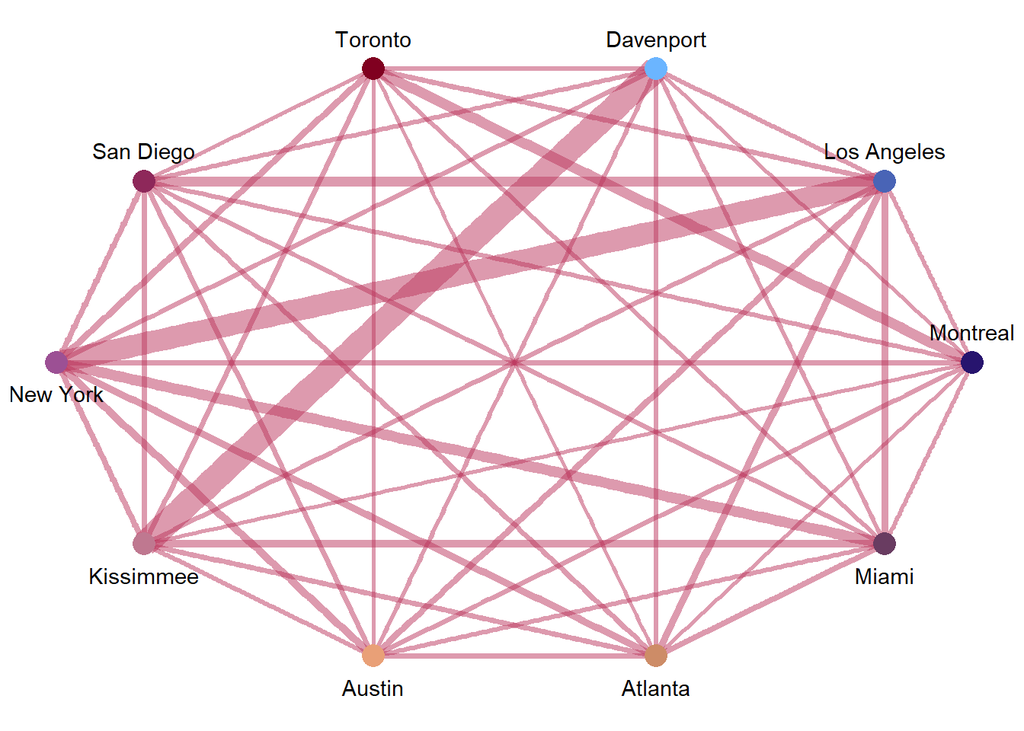